# CausalImpact

Linh Tran

5/10/2021

- What does the package `CausalImpact` do? - Estimate causal effect of a designed intervention on a time series. E.g.: How many additional daily clicks generated by an advertising campaign? or when randomized experiment is not available.
- How does it work?
- Given a response time series (e.g clicks) and a set of control time series (e.g clicks in non-affected markets or clicks on the other sites), the package construct a Bayesian structural time-series model.
- Model then used to predict the counterfactual i.e. how the response metric would have evolved after the intervention if the intervention had never occured.
- Assumptions:
- There is a set control time series that were *themselves not affected by the intervention*
- Relationship between covariates and treated time series as established during pre-period remains stable through out the post-period. | Covariates are not affected by the intervention.
- Given a response time series and a set of control time series, the function constructs a time-series model, performs posterior inference on the counterfactual, and returns a `CausalImpact` object

# Example dataset

Create a simple dataset contains a response variable `y` and a predictor `x1`. The example data has 100 observations. We create an intervention effect by lifting the response variable by 10 units after timepoint 71.

```r
set.seed(1)
x1 <- 100 + arima.sim(model = list(ar = 0.999), n = 100)
y <- 1.2 * x1 + rnorm(100)
y[71:100] <- y[71:100] + 10
data <- cbind(y, x1)

dim(data)
```

```
## [1] 100   2
```

```r
head(data)
```

```
##             y       x1
## [1,] 105.2950 88.21513
## [2,] 105.8943 88.48415
## [3,] 106.6209 87.87684
## [4,] 106.1572 86.77954
## [5,] 101.2812 84.62243
## [6,] 101.4484 84.60650
```

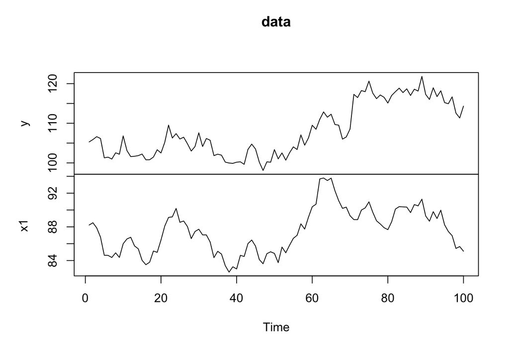

```r
#visualization
plot(data)
```

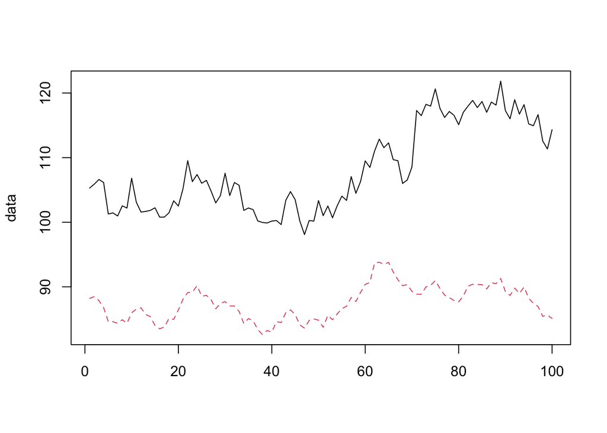

```r
matplot(data, type = "l")
```

# Running an analysis

To estimate a causal effect, we begin by specifying which period in the data should be used for training the model (pre-intervention period) and which period for computing a counterfactual prediction (post-intervention period)

```r
pre.period <- c(1,70)  #time points 1 - 70 will be used for training
post.period <- c(71,100) #timepoints 71-100 will be used for computing predictions
```

```r
impact <- CausalImpact(data, pre.period, post.period )
impact
```

```
## Posterior inference {CausalImpact}
##
##                          Average        Cumulative
## Actual                   117            3511
## Prediction (s.d.)        107 (0.37)     3196 (10.96)
## 95% CI                   [106, 107]     [3175, 3217]
##
## Absolute effect (s.d.)   11 (0.37)      315 (10.96)
## 95% CI                   [9.8, 11]      [294.0, 336]
##
## Relative effect (s.d.)   9.9% (0.34%)   9.9% (0.34%)
## 95% CI                   [9.2%, 11%]    [9.2%, 11%]
##
## Posterior tail-area probability p:   0.00101
## Posterior prob. of a causal effect:  99.8993%
##
## For more details, type: summary(impact, "report")
```

# Plotting the results

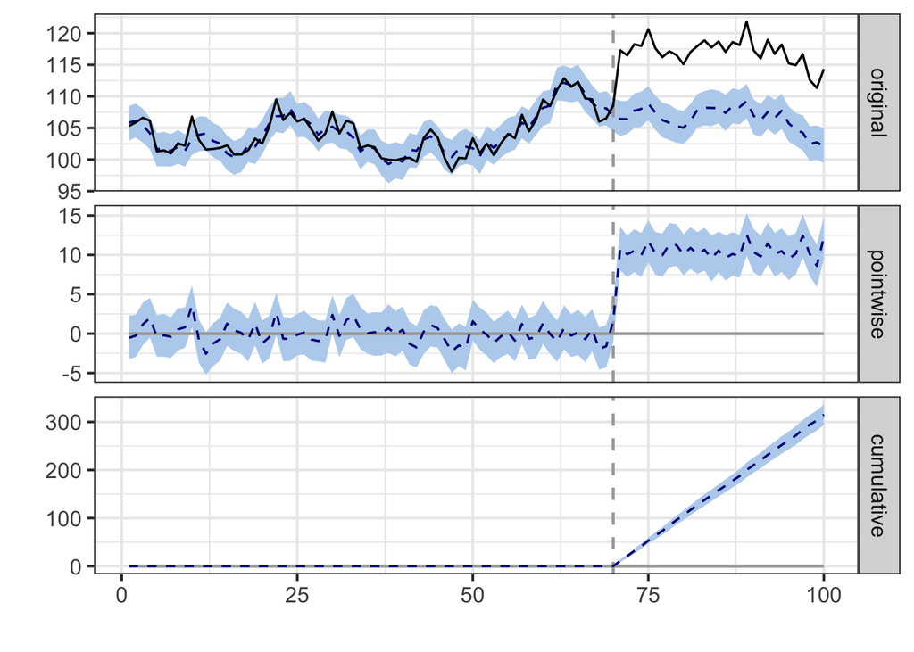

```r
plot(impact)
```

- The 1st panel show the data and a counterfactual prediction for the post-treatment period.
- The 2nd panel shows the **difference** between observed data and counterfactual predictions => pointwise causal effect
- The 3rd panel adds up the pointwise contributions from the 2nd panel, resulting in a plot of the cumulative effect of the intervention.